# 6조 2번 과제 - House Prices Prediction Dataset

# 결측치가 포함된 독립변수 34개 수정하기

# 결측치 포함된 변수 확인

다른 변수와 유의미한 관계를 갖는 변수를 찾는다면, 그룹핑 하기 결측치는 character 타입은 integer 타입으로 변환했고, 순서형 변수나 순서가 없는 범주형은 factor로 변환했다. ‘one-hot-encoding’(model.matrix 함수)을 써서 factor를 numeric으로 변환할 것이다.

```r
#결측치 변수 별로 내림차순 정렬
sort(colSums(sapply(all[NAcol], is.na)), decreasing = TRUE)
```

```
      PoolQC  MiscFeature        Alley        Fence    SalePrice
        2909         2814         2721         2348         1459
 FireplaceQu  LotFrontage  GarageYrBlt GarageFinish   GarageQual
        1420          486          159          159          159
  GarageCond   GarageType     BsmtCond BsmtExposure     BsmtQual
         159          157           82           82           81
BsmtFinType2 BsmtFinType1   MasVnrType   MasVnrArea     MSZoning
          80           79           24           23            4
   Utilities BsmtFullBath BsmtHalfBath   Functional  Exterior1st
           2            2            2            2            1
 Exterior2nd   BsmtFinSF1   BsmtFinSF2    BsmtUnfSF  TotalBsmtSF
           1            1            1            1            1
  Electrical  KitchenQual   GarageCars   GarageArea     SaleType
           1            1            1            1            1
```

```r
cat('There are', length(NAcol), 'columns with missing values')
```

```
There are 35 columns with missing values
```

’SalePrice’제외하고 34개의 독립 변수에서 NA를 수정해야함.

|  | PoolArea | PoolQC | OverallQual |
| --- | --- | --- | --- |
| 2421 | 368 | 0 | 4 |
| 2504 | 444 | 0 | 6 |
| 2600 | 561 | 0 | 3 |

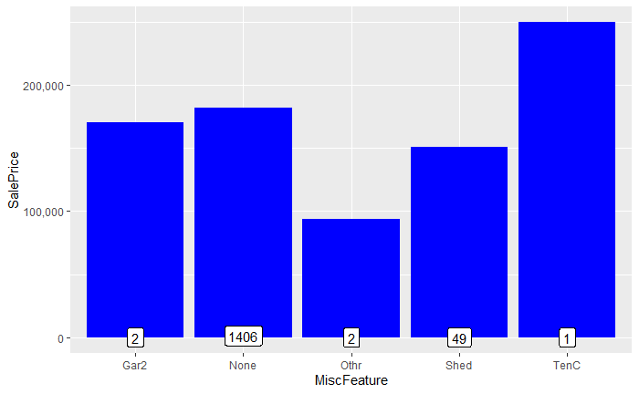

```r
ggplot(all[!is.na(all$SalePrice),], aes(x = MiscFeature, y = SalePrice)) +
  geom_bar(stat = 'summary', fun.y = 'median', fill = 'blue') +
  scale_y_continuous(breaks = seq(0, 800000, by = 100000), labels = comma) +
  geom_label(stat = 'count', aes(label = ..count.., y = ..count..)) #막대 그래프 count 라벨링
```

```r
table(all$MiscFeature)
```

```
Gar2 None Othr Shed TenC
   5 2814    4   95    1
```

빈도를 볼 때, 그 변수는 무의미해 보인다. 헛간이 있는 낮은 가격은 ’no Garage’일 것이라 추측한다. 테니스 코트가 있는 집은 비싸고, 단 한 곳 뿐이었다.

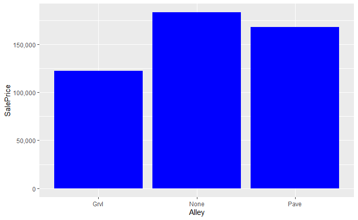

```r
ggplot(all[!is.na(all$SalePrice),], aes(x = Alley, y = SalePrice)) +
  geom_bar(stat = 'summary', fun.y = 'median', fill = 'blue') +
  scale_y_continuous(breaks = seq(0, 200000, by = 50000), labels = comma)
```

```r
table(all$Alley)
```

```
Grvl None Pave
 120 2721   78
```

```r
table(all$Fence)
```

```
GdPrv  GdWo MnPrv  MnWw  None
  118   112   329    12  2348
```

| Fence | median | counts |
| --- | --- | --- |
| GdPrv | 167500 | 59 |
| GdWo | 138750 | 54 |
| MnPrv | 137450 | 157 |
| MnWw | 130000 | 11 |
| None | 173000 | 1179 |

```r
table(all$Fireplaces)   #Fireplaces의 범주별 개수 확인
```

```
   0    1    2    3    4
1420 1268  219   11    1
```

FireplaceQu 결측치의 수는 fireplaces 변수가 0인 수와 일치한다. 이건 이 결측치를 ’no fireplace’로 바꾸는데 무리가 없다는 걸 말한다. 이건 순서형 범주이고, Pool Quality를 위해 이전에 만들어둔 Qulaites 벡터를 쓰겠다.

```r
sum(table(all$Fireplaces)) #합산한 개수가 변수의 총 개수와 같은지 확인
```

```
[1] 2919
```

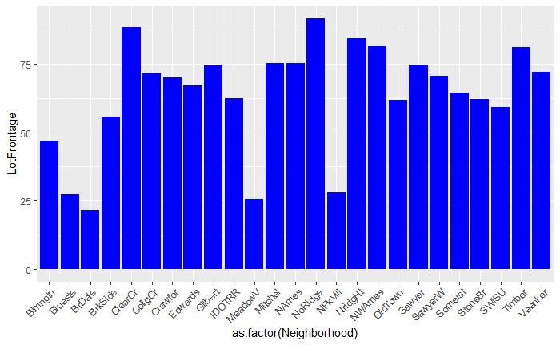

```r
# LotFrontage: Linear feet of street connected to property
ggplot(all[!is.na(all$LotFrontage),],
       aes(x = as.factor(Neighborhood), y = LotFrontage)) +
       geom_bar(stat = 'summary', fun.y = 'median', fill = 'blue') +
       theme(axis.text.x = element_text(angle = 45, hjust = 1)) # Text 45도 기울기, 높이는 1로 설정
```

```r
table(all$LotShape)
```

```
   0    1    2    3
  16   76  968 1859
```

```r
sum(table(all$LotShape))
```

```
[1] 2919
```

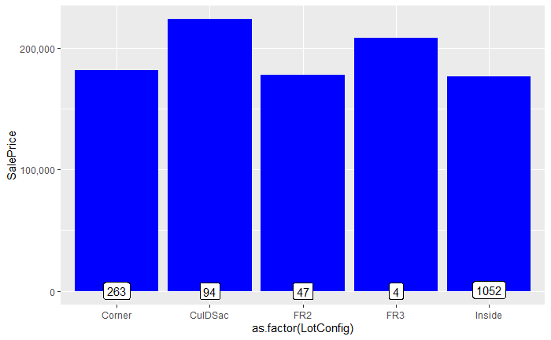

```r
# LotConfig: Lot configuration
ggplot(all[!is.na(all$SalePrice),], aes(x = as.factor(LotConfig), y = SalePrice)) +
  geom_bar(stat = 'summary', fun.y = 'median', fill = 'blue') +
  scale_y_continuous(breaks = seq(0, 800000, by = 100000), labels = comma) +
  geom_label(stat = 'count', aes(label = ..count.., y = ..count..))
```

```r
table(all$LotConfig)
```

```
 Corner CulDSac     FR2     FR3  Inside
    511     176      85      14    2133
```

```r
sum(table(all$LotConfig))
```

```
[1] 2919
```

결측치의 개수는 2개 변수(GarageCars, GarageArea)가 1개, 1개 변수(GarageType)가 157개, 나머지 4개 변수가 159개이다. 먼저 159개의 결측치가 있는 ** GarageYrBlt:창고 건축년도 ** 의 결측치 값을 YearBuilt의 값으로 대체하겠다. (리모델링이나 증축을 하지 않은 YearBuilt의 default값이 YearReomdAdd 변수와 유사하다.) 결측치는 문자형 타입이며 ’no garage’를 의미하기에, 157개와 159개의 결측치를 가진 세 변수의 차이점을 찾아보겠다.

```r
#157개의 결측치가 159개 결측치의 변수와 동일한 관측치인지 확인해 보겠다.
length(which(is.na(all$GarageType) & is.na(all$GarageFinish) & is.na(all$GarageCond) & is.na(all$GarageQual)))
```

```
[1] 157
```

|  | GarageCars | GarageArea | GarageType | GarageCond | GarageQual | GarageFinish |
| --- | --- | --- | --- | --- | --- | --- |
| 2127 | 1 | 360 | Detchd | NA | NA | NA |
| 2577 | NA | NA | Detchd | NA | NA | NA |

GarageType’의 157개 결측치는 ’GarageCondition’, ‘GarageQuality’, ’GarageFinish’에 있는 결측치를 나타낸다. 2127과 2577 두채의 다른 집을 찾았다. 2127은 창고가 있지만, 2577은 없는 것처럼 보인다. 즉 총 158개의 집이 창고가 없으며, 2127의 결측치는 159개 세 변수의 가장 많은 값으로 대체하겠다.

|  | GarageYrBlt | GarageCars | GarageArea | GarageType | GarageCond | GarageQual | GarageFinish |
| --- | --- | --- | --- | --- | --- | --- | --- |
| 2127 | 1910 | 1 | 360 | Detchd | TA | TA | Unf |

상기 두 변수 다 1개의 결측치가 있으며, 그건 2577 house이다. 이건 지금껏의 관측에서 찾아봤듯이 모든 Garage 변수에서 2577은 ’no Garage’를 나타낸다.

```r
# 문자형 변수인 4 변수의 결측치가 모두 158개인지 확인해보겠다.
length(which(is.na(all$GarageType) & is.na(all$GarageFinish) & is.na(all$GarageCond) & is.na(all$GarageQual)))
```

```
[1] 158
```

4개의 문자형 변수는 Garage와 연관이 있으며 모든 셋에 158개의 동일한 결측치가 있고, 이건 “No Garage”를 의미한다. 이 섹션에서 이걸 수정했다.

```r
table(all$GarageType)
```

```
   2Types    Attchd   Basment   BuiltIn   CarPort    Detchd No Garage
       23      1723        36       186        15       778       158
```

```r
table(all$GarageFinish)
```

```
   0    1    2    3
 158 1231  811  719
```

```r
table(all$GarageQual)
```

```
   0    1    2    3    4    5
 158    5  124 2605   24    3
```

```r
table(all$GarageCond)
```

```
   0    1    2    3    4    5
 158   14   74 2655   15    3
```

```r
# 79개의 결측치가 80 이상의 결측치의 값과 동일한 관측치를 보이는지 확인하겠다.
length(which(is.na(all$BsmtQual) & is.na(all$BsmtCond) & is.na(all$BsmtExposure) &
               is.na(all$BsmtFinType1) & is.na(all$BsmtFinType2)))
```

```
[1] 79
```

|  | BsmtQual | BsmtCond | BsmtExposure | BsmtFinType1 | BsmtFinType2 |
| --- | --- | --- | --- | --- | --- |
| 333 | Gd | TA | No | GLQ | NA |
| 949 | Gd | TA | NA | Unf | Unf |
| 1488 | Gd | TA | NA | Unf | Unf |
| 2041 | Gd | NA | Mn | GLQ | Rec |
| 2186 | TA | NA | No | BLQ | Unf |
| 2218 | NA | Fa | No | Unf | Unf |
| 2219 | NA | TA | No | Unf | Unf |
| 2349 | Gd | TA | NA | Unf | Unf |
| 2525 | TA | NA | Av | ALQ | Unf |

확인 결과, 79채가 지하실이 없는 것처럼 보인다. 그 중 9채는 중간 중간 결측치가 보이는데, 이건 각 변수를 내림차순으로 정렬해 가장 빈도수가 높은 값으로 대체하겠다.

79~82개의 결측치를 가진 5개 변수는 지하실이 없어 보여, factorize/ hot encode하겠다.

```r
table(all$BsmtQual)
```

```
   0    2    3    4    5
  79   88 1285 1209  258
```

```r
table(all$BsmtCond)
```

```
   0    1    2    3    4
  79    5  104 2609  122
```

```r
table(all$BsmtExposure)
```

```
   0    1    2    3    4
  79 1907  239  418  276
```

```r
table(all$BsmtFinType1)
```

```
  0   1   2   3   4   5   6
 79 851 154 288 269 429 849
```

```r
table(all$BsmtFinType2)
```

```
   0    1    2    3    4    5    6
  79 2494   87  105   68   52   34
```

|  | BsmtQual | BsmtFullBath | BsmtHalfBath | BsmtFinSF1 | BsmtFinSF2 | BsmtUnfSF | TotalBsmtSF |
| --- | --- | --- | --- | --- | --- | --- | --- |
| 2121 | 0 | NA | NA | NA | NA | NA | NA |
| 2189 | 0 | NA | NA | 0 | 0 | 0 | 0 |

확인 결과 2채의 집에 결측치를 발견했고, 결측치는 0으로 대체하겠다.

```r
table(all$BsmtFullBath)
```

```
   0    1    2    3
1707 1172   38    2
```

```r
table(all$BsmtHalfBath)
```

```
   0    1    2
2744  171    4
```

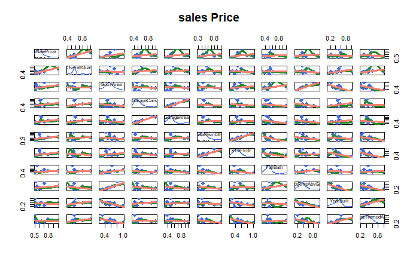

변수별 분포와 선형 관계를 살펴 보았음.

```r
summary(cor_numVar.m.pca)
```

```
Importance of components:
                          PC1    PC2    PC3     PC4
Standard deviation     1.9374 1.6226 1.3318 0.96090
Proportion of Variance 0.3753 0.2633 0.1774 0.09233
Cumulative Proportion  0.3753 0.6386 0.8160 0.90833
                           PC5     PC6     PC7     PC8
Standard deviation     0.72620 0.47896 0.29091 0.22282
Proportion of Variance 0.05274 0.02294 0.00846 0.00496
Cumulative Proportion  0.96106 0.98400 0.99247 0.99743
                           PC9      PC10
Standard deviation     0.16028 4.213e-17
Proportion of Variance 0.00257 0.000e+00
Cumulative Proportion  1.00000 1.000e+00
```

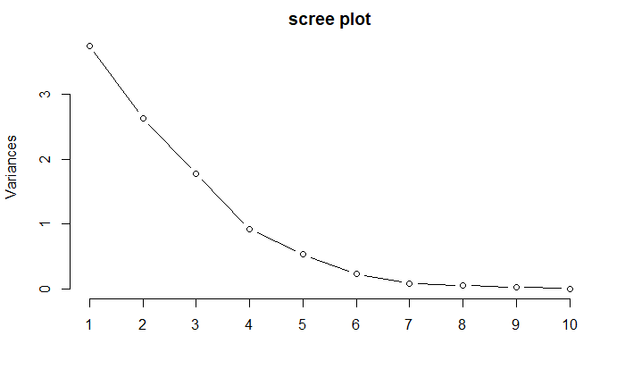

스크리그림을 그렸을때도 4이후 완만해져서 주성분을 3개까지 쓰는게 좋아보임.

```r
cor_numVar.m.pca$x[,1:2]
```

```
                    PC1         PC2
OverallQual  -1.1950901  0.08734093
GrLivArea     2.4623530  0.62508829
GarageCars   -1.2656513 -0.65612875
GarageArea   -1.0433417 -1.20713279
TotalBsmtSF   0.3804716 -2.46211464
X1stFlrSF     1.3596713 -2.31197398
FullBath      0.7766426  2.18744164
TotRmsAbvGrd  3.1696833  1.31670460
YearBuilt    -2.6126525  0.68480494
YearRemodAdd -2.0320862  1.73596976
```

```r
summary(lm)
```

```
Call:
lm(formula = SalePrice ~ OverallQual + GrLivArea + GarageCars,
    data = all)

Residuals:
    Min      1Q  Median      3Q     Max
-340718  -21675   -2085   19500  300177

Coefficients:
              Estimate Std. Error t value Pr(>|t|)
(Intercept) -98832.493   4842.897  -20.41   <2e-16 ***
OverallQual  27104.826   1072.182   25.28   <2e-16 ***
GrLivArea       50.674      2.552   19.86   <2e-16 ***
GarageCars   21298.960   1807.065   11.79   <2e-16 ***
---
Signif. codes:
0 ‘***’ 0.001 ‘**’ 0.01 ‘*’ 0.05 ‘.’ 0.1 ‘ ’ 1

Residual standard error: 40620 on 1456 degrees of freedom
  (결측으로 인하여 1459개의 관측치가 삭제되었습니다.)
Multiple R-squared:  0.7391,    Adjusted R-squared:  0.7385
F-statistic:  1375 on 3 and 1456 DF,  p-value: < 2.2e-16
```

SalePrice ~ OverallQual + GrLivArea + GarageCars 모델의 모든 독립변수는 p값이 매우 작으므로 모두 유의하다고 볼 수 있음. 이 모형의 설명력은 73.85%이며, 모델의 p값도 매우 작으므로 모델이 유의하다고 볼 수있음.

```r
lm.beta(lm)
```

```
OverallQual   GrLivArea  GarageCars
  0.4718618   0.3351896   0.2003591
```

표준화계수 베타를 확인 해보았을때도 주성분분석을 했을때와 유사한 결과가 나왔음.

```r
cor_numVar.cv
```

```
Call:  cv.glmnet(x = x, y = y, family = "gaussian", alpha = 0)

Measure: Mean-Squared Error

    Lambda Index   Measure        SE Nonzero
min   4073    97 1.917e+09 148429519      25
1se 105703    62 2.059e+09 178921239      25
```

변수가 많아서 릿지 선택함-> 높은 분산을 가지는 상황에서 가장 잘 작동하기 때문, 분산은 크게 감소할 것임. x는 숫자형 변수들, y는 SalesPrice로 릿지회귀모형을 만듦. 영향을 거의 미치지 않는 변수에 대하여 0에 가까운 가중치를 줌.

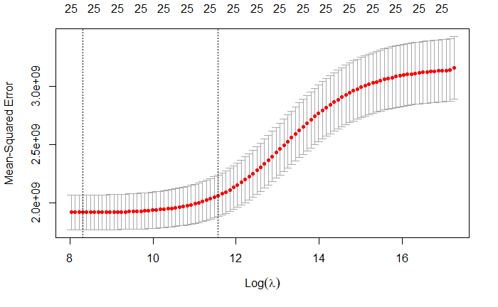

```r
best.lam
```

```
[1] 4073.289
```

최적의 람다는 4073.289

```r
a
```

```
 [1] -3.659706e+05 -1.793732e+04 -7.215564e+03
 [4] -2.329954e+03 -5.468597e+01 -4.873333e+01
 [7] -1.313611e+01 -4.599712e+00 -4.335597e+00
[10]  0.000000e+00  0.000000e+00  0.000000e+00
[13]  0.000000e+00  0.000000e+00  0.000000e+00
[16]  0.000000e+00  0.000000e+00  0.000000e+00
[19]  0.000000e+00  0.000000e+00  6.294100e-01
[22]  7.337499e-01  1.116351e+01  1.179767e+01
[25]  1.487561e+01  1.661152e+01  1.764249e+01
[28]  3.115523e+01  3.560849e+01  3.764749e+01
[31]  2.212322e+02  2.335544e+02  1.258543e+03
[34]  2.381201e+03  2.557377e+03  4.583616e+03
[37]  8.252020e+03
```